# Figure 2: RIG-I-only vs STAT-only signatures in influenza-infected A549 cells (scRNA-Seq)

Carlos Ramirez

2026-10-27 17:03:58

This markdown reproduces the panels of **Figure 2**. We project the RIG-I-only and STAT-only (IFN-only) signatures, derived from the A549 bulk model in Figure 1, onto single-cell RNA-Seq data of A549 cells infected with influenza A virus (H3N2) over a time course (uninfected, 8, 10, 12, 14 and 16 h post infection; [Rivera et al. 2025, GSE287024](https://www.ncbi.nlm.nih.gov/geo/query/acc.cgi?acc=GSE287024)). Every cell is scored with both signatures (Seurat `AddModuleScore`), and cells are classified into two quadrants of the RIG-I-only vs STAT-only score plane:

- **Quadrant I**: high RIG-I-only score and low STAT-only score (`rigi_only >= 0.1` and `stat_only <= 0.05`), i.e. cells with direct RIG-I activity but no IFN-receptor signalling.
- **Quadrant II**: high STAT-only score and low RIG-I-only score (`stat_only >= 0.05` and `rigi_only < 0`), i.e. bystander cells responding to secreted IFN.

Panels produced (all saved in `figures/figure_02/`):

| Panel file | Content |
| --- | --- |
| `a549_quadrantes_across_time_rivera.pdf` | RIG-I-only vs STAT-only scores per time point, coloured by quadrant |
| `barplot_prop_quadrants_rivera.pdf` | Proportion of all cells falling in quadrant I / II per time point |
| `quantification_interferon_expression_rivera.pdf` | IFNB1, IFNL1 and IFNL2 expression in quadrant I vs II cells per time point (Wilcoxon test) |
| `oasl_ifnl1_ha_rigi_vs_stat.pdf` | RIG-I-only vs STAT-only scores of infected cells coloured by IFNL1, OASL and viral HA expression |
| `oasl_vs_rigi.pdf` | Viral HA expression vs OASL expression / RIG-I-only score, coloured and sized by IFNL1 |

The code was taken from the original analysis script `/media/ag-cherrmann/cramirez/interferon_model/scripts/R/july_2026/02_scRNASeq_projections_Rivera.Rmd` keeping only what is needed for these panels; plotting code, PDF sizes and aesthetics are unchanged.

# Input data

| Input | Absolute path / source |
| --- | --- |
| Raw 10x count matrices (GEO GSE287024, samples GSM8736732-GSM8736742; `*_matrix.mtx.gz`, `*_features.tsv.gz`, `*_barcodes.tsv.gz`) | `/media/bq-storage/ag-cherrmann/cramirez/data/Rivera_H3N2_A549/GSE287024_RAW/` |
| Processed Seurat object (merged, normalised, PCA/UMAP; cached output of the raw-data processing below; contains the sample/time-point annotation in its metadata: `orig.ident`, `sample`, `condition`, `… | `/media/bq-storage/ag-cherrmann/cramirez/data/Rivera_H3N2_A549/GSE287024_RAW/a549_iav_rivera_scRNASeq.rds` |
| Sample annotation | defined in code below from the GEO sample names (chunk `selecting_samples`) |
| RIG-I-only / STAT-only signatures (written by `figure_01.Rmd`) | `/media/bq-storage/ag-cherrmann/cramirez/decoupling_rigi_ifn/analysis/figure_01/rigi_vs_stat_only_signatures.rds` (`path2signs` in `settings.R`) |
| Shared settings (paths, colours) | `/media/bq-storage/ag-cherrmann/cramirez/decoupling_rigi_ifn/scripts/R/settings.R` |

No MSigDB gene sets are used for the panels of this figure.

```r
library(ggplot2)
library(dplyr)
library(readr)
library(purrr)
library(scales)
library(Seurat)
library(stringr)
library(RColorBrewer)
library(ggpubr)
library(gridExtra)

source("/media/bq-storage/ag-cherrmann/cramirez/decoupling_rigi_ifn/scripts/R/settings.R")
```

## Initial settings

Output folders of this section (`figures/figure_02/` and `analysis/figure_02/` in the repository) and the raw-data flags. Both `reprocess` and `rerun` were `FALSE` in the original analysis: the cached processed Seurat object is loaded instead of re-processing the raw data.

```r
dirs <- section_dirs("figure_02")
path2figures <- dirs$figures
path2analysis <- dirs$analysis

knitr::opts_chunk$set(
  message = FALSE,
  warning = FALSE,
  error = FALSE
)

reprocess <- FALSE
rerun <- FALSE
```

# Loading the scRNA-Seq data

Raw data folder (GEO GSE287024 supplementary files).

```r
path2rivera <- '/media/bq-storage/ag-cherrmann/cramirez/data/Rivera_H3N2_A549/GSE287024_RAW/'

list.files(path2rivera)
```

```
##  [1] "a549_iav_rivera_scRNASeq.rds"
##  [2] "GSM8736732_Uninfected_barcodes.tsv.gz"
##  [3] "GSM8736732_Uninfected_features.tsv.gz"
##  [4] "GSM8736732_Uninfected_matrix.mtx.gz"
##  [5] "GSM8736733_Infected_8hrs_1_barcodes.tsv.gz"
##  [6] "GSM8736733_Infected_8hrs_1_features.tsv.gz"
##  [7] "GSM8736733_Infected_8hrs_1_matrix.mtx.gz"
##  [8] "GSM8736734_Infected_8hrs_2_barcodes.tsv.gz"
##  [9] "GSM8736734_Infected_8hrs_2_features.tsv.gz"
## [10] "GSM8736734_Infected_8hrs_2_matrix.mtx.gz"
## [11] "GSM8736735_Infected_10hrs_1_barcodes.tsv.gz"
## [12] "GSM8736735_Infected_10hrs_1_features.tsv.gz"
## [13] "GSM8736735_Infected_10hrs_1_matrix.mtx.gz"
## [14] "GSM8736736_Infected_10hrs_2_barcodes.tsv.gz"
## [15] "GSM8736736_Infected_10hrs_2_features.tsv.gz"
```

[output cut: 19 more lines]

Sample annotation: one uninfected control and two replicates per infection time point.

```r
samples <- tibble::tibble(
  sample_id = c(
    "Uninfected",
    "Infected_8h_1", "Infected_8h_2",
    "Infected_10h_1", "Infected_10h_2",
    "Infected_12h_1", "Infected_12h_2",
    "Infected_14h_1", "Infected_14h_2",
    "Infected_16h_1", "Infected_16h_2"
  ),
  prefix = c(
    "GSM8736732_Uninfected",
    "GSM8736733_Infected_8hrs_1",
    "GSM8736734_Infected_8hrs_2",
    "GSM8736735_Infected_10hrs_1",
    "GSM8736736_Infected_10hrs_2",
    "GSM8736737_Infected_12hrs_1",
    "GSM8736738_Infected_12hrs_2",
    "GSM8736739_Infected_14hrs_1",
    "GSM8736740_Infected_14hrs_2",
    "GSM8736741_Infected_16hrs_1",
    "GSM8736742_Infected_16hrs_2"
  )
)
```

## Raw-data processing (not evaluated)

The next three chunks document how the cached Seurat object was built from the raw 10x matrices: one Seurat object per sample (cells with at least 3000 detected genes), sample annotation added to the metadata, merging, log-normalisation, scaling, PCA and UMAP. They are **not evaluated** (`eval = FALSE`; the original guarded them with `reprocess`/`rerun = FALSE`) because the processing is slow and its result is stored in `a549_iav_rivera_scRNASeq.rds`, which is loaded below. Note that the saving step would write into the data folder; it must not be run from this repository without changing the output path.

```r
path <- path2rivera

if ( reprocess == TRUE ){
          seurat_list <- lapply(seq_len(nrow(samples)), function(i) {

          counts <- ReadMtx(
            mtx = file.path(path, paste0(samples$prefix[i], "_matrix.mtx.gz")),
            features = file.path(path, paste0(samples$prefix[i], "_features.tsv.gz")),
            cells = file.path(path, paste0(samples$prefix[i], "_barcodes.tsv.gz"))
          )

          obj <- CreateSeuratObject(
            counts = counts,
            project = samples$sample_id[i],
            min.cells = 0,
            min.features = 3000
          )

          # Add metadata
          obj$sample     <- samples$sample_id[i]
          obj$condition  <- ifelse(str_detect(samples$sample_id[i], "Uninfected"),
                                   "Uninfected", "Infected")
          obj$timepoint  <- str_extract(samples$sample_id[i], "\\d+h")
          obj$replicate  <- str_extract(samples$sample_id[i], "_\\d$")

          return(obj)
        })

        names(seurat_list) <- samples$sample_id
}
```

Merging the per-sample Seurat objects.

```r
if ( reprocess == TRUE ) {
       merged_obj <- merge(
  x = seurat_list[[1]],
  y = seurat_list[-1],
  add.cell.ids = names(seurat_list),
  project = "Rivera_concat"
)
merged_obj

rm(seurat_list)
}
```

Standard pre-processing and saving of the cached object.

```r
if ( rerun == TRUE ) {
        DefaultAssay(merged_obj) <- "RNA"
        merged_obj <- NormalizeData(merged_obj, verbose = FALSE)
        merged_obj <- FindVariableFeatures(merged_obj,
                                   nfeatures = 20000)
        merged_obj <- ScaleData(merged_obj, verbose = FALSE)
        merged_obj <- RunPCA(merged_obj, npcs = 50)
        merged_obj <- RunUMAP(merged_obj, dims = 1:49, verbose = FALSE)

        saveRDS(merged_obj,
                file = paste0(path2rivera,
                              "/a549_iav_rivera_scRNASeq.rds"),
                compress = TRUE)
}
```

## Loading the cached processed object

Loading the processed Seurat object (same file loaded by the original analysis).

```r
merged_obj <- readRDS(file = paste0(path2rivera,
                              "/a549_iav_rivera_scRNASeq.rds"))
merged_obj
```

```
## An object of class Seurat
## 33702 features across 24282 samples within 1 assay
## Active assay: RNA (33702 features, 20000 variable features)
##  23 layers present: counts.Uninfected, counts.Infected_8h_1, counts.Infected_8h_2, counts.Infected_10h_1, counts.Infected_10h_2, counts.Infected_12h_1, counts.Infected_12h_2, counts.Infected_14h_1, counts.Infected_14h_2, counts.Infected_16h_1, counts.Infected_16h_2, data.Uninfected, data.Infected…
##  2 dimensional reductions calculated: pca, umap
```

```r
table(merged_obj$orig.ident)
```

```
##
## Infected_10h_1 Infected_10h_2 Infected_12h_1 Infected_12h_2 Infected_14h_1
##           2097            368           2285           1856           2642
## Infected_14h_2 Infected_16h_1 Infected_16h_2  Infected_8h_1  Infected_8h_2
##           1851           1962           1828           1268           2947
##     Uninfected
##           5178
```

Score columns already stored in the cached object (if any). They are kept aside to compare with the scores recomputed below.

```r
cached_score_cols <- intersect(c("stat_only1", "rigi_only2"),
                               colnames(merged_obj@meta.data))
cached_score_cols
```

```
## [1] "stat_only1" "rigi_only2"
```

```r
cached_scores <- merged_obj@meta.data[, cached_score_cols, drop = FALSE]
```

# Scoring cells with the RIG-I-only / STAT-only signatures

## Loading signatures

Signatures from Figure 1 (`path2signs`). As in the original analysis, genes whose symbol contains “IFN” are removed (to avoid scoring the interferon transcripts themselves, which are later used as read-outs) and the list is re-ordered to `stat_only`, `rigi_only`. Because of this order, `AddModuleScore` names the score columns `stat_only1` and `rigi_only2`.

```r
signatures <- readRDS(path2signs)
signatures <- lapply(signatures,
                     function(genes){
                             grep(pattern = 'IFN',
                                  x = genes,
                                  value = TRUE,
                                  invert = TRUE)
                     })
signatures <- signatures[c(2, 1)]
str(signatures)
```

```
## List of 2
##  $ stat_only: chr [1:99] "PNPT1" "TRIM5" "CSF1" "ZNF711" ...
##  $ rigi_only: chr [1:94] "EGR4" "CXCL11" "FOSB" "EGR2" ...
```

## Scoring cells

Module scores with Seurat `AddModuleScore` (default `seed = 1`, hence deterministic).

```r
merged_obj <- AddModuleScore(
  object = merged_obj,
  features = signatures,
  name = names(signatures)
)
```

Comparison of recomputed scores with those stored in the cached object (only if the cached object contained score columns).

```r
if (length(cached_score_cols) > 0) {
        for (sc in cached_score_cols) {
                d <- merged_obj@meta.data[rownames(cached_scores), sc] -
                        cached_scores[[sc]]
                cat(sc, ": max |recomputed - cached| =",
                    max(abs(d), na.rm = TRUE), "\n")
        }
} else {
        cat("The cached object does not contain stat_only1 / rigi_only2 scores;",
            "scores are computed here only.\n")
}
```

```
## stat_only1 : max |recomputed - cached| = 0
## rigi_only2 : max |recomputed - cached| = 0
```

## Extracting scores and expression values

Cell metadata with a discrete time-point factor (uninfected cells = `Control`) plus the log-normalised expression of IFNL1, IFNL2, IFNB1, OASL and the viral haemagglutinin (HA) transcript.

```r
md <- merged_obj@meta.data
md$'time_discrete' <- md$timepoint
md$'time_discrete'[is.na(md$'time_discrete')] <- 'Control'
md$'time_discrete' <- factor(md$'time_discrete',
                             levels = c('Control', '8h', '10h',
                                        '12h', '14h', '16h'))

df <- FetchData(merged_obj, vars = c('IFNL1', 'HA', 'OASL',
                                     'IFNB1', 'IFNL2'))
all(rownames(df) == colnames(merged_obj))
```

```
## [1] TRUE
```

```r
md$'IFNL1' <- df$IFNL1
md$'IFNB1' <- df$IFNB1
md$'IFNL2' <- df$IFNL2
md$'HA' <- df$HA
md$'OASL' <- df$OASL
```

# Quadrant classification (panel `a549_quadrantes_across_time_rivera.pdf`)

Cells are assigned to quadrant I (`stat_only1 <= 0.05` and `rigi_only2 >= 0.1`) or quadrant II (`stat_only1 >= 0.05` and `rigi_only2 < 0`); all other cells are `NA`. The scatter plot shows the two scores per time point coloured by quadrant.

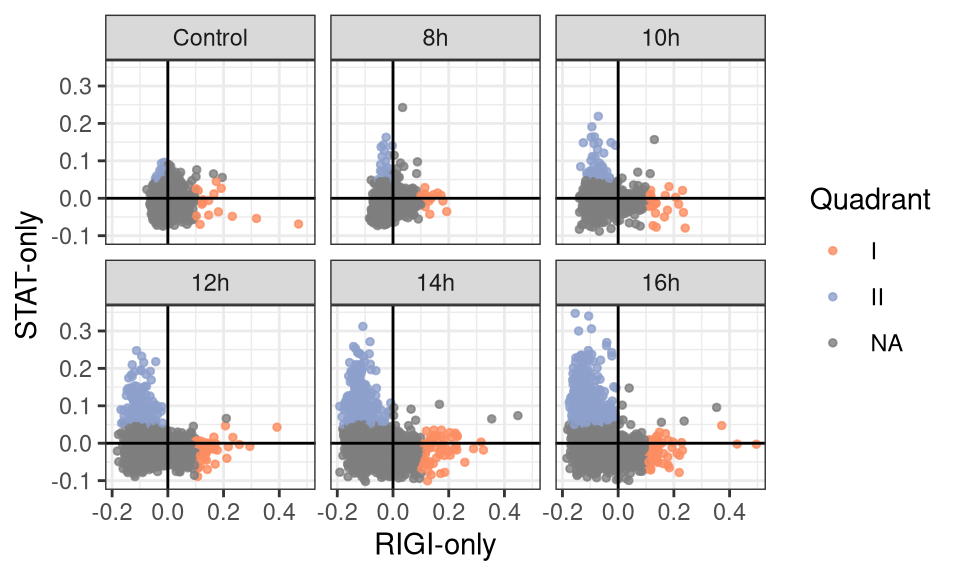

```r
md$quadrant_q <- with(md,
  ifelse(stat_only1 <= 0.05 & rigi_only2 >= 0.1, "I",
  ifelse(stat_only1 >= 0.05 & rigi_only2 < -0.0, "II", NA))
)

cols <- brewer.pal(4, "Set2")[2:4]
names(cols) <- c("I", "II")

f1 <- ggplot(md, aes(x = rigi_only2, y = stat_only1,
               color = quadrant_q)) +
  geom_point(alpha = 0.8, size = 1) +
  geom_hline(yintercept = 0) +
  geom_vline(xintercept = 0) +
        facet_wrap(~time_discrete) +
        scale_color_manual(values = cols) +
  labs(
    x = "RIGI-only",
    y = "STAT-only",
    color = "Quadrant"
  ) +
  theme_bw()

f1
```

```r
pdf(file = paste0(path2figures,
                  '/a549_quadrantes_across_time_rivera.pdf'),
    width=5.0, height=3.0)
f1
dev.off()
```

Saving the per-cell scores, quadrant assignment and expression values used by all panels.

```r
cell_table <- md %>%
        tibble::rownames_to_column("cell") %>%
        dplyr::select(cell, orig.ident, timepoint, time_discrete,
                      stat_only1, rigi_only2, quadrant_q,
                      IFNL1, IFNL2, IFNB1, OASL, HA)
write_tsv(cell_table,
          file = paste0(path2analysis, "/rivera_cell_scores_quadrants.tsv.gz"))
table(cell_table$time_discrete, cell_table$quadrant_q, useNA = "ifany")
```

```
##
##              I   II <NA>
##   Control   18   25 5135
##   8h        18   19 4178
##   10h       29   45 2391
##   12h       54  162 3925
##   14h       65  269 4159
##   16h       62  337 3391
```

# IFN expression per quadrant (panel `quantification_interferon_expression_rivera.pdf`)

Log expression of IFNB1, IFNL1 and IFNL2 in quadrant I vs quadrant II cells per time point; significance of I vs II within each time point by Wilcoxon test (`ggpubr::stat_compare_means`).

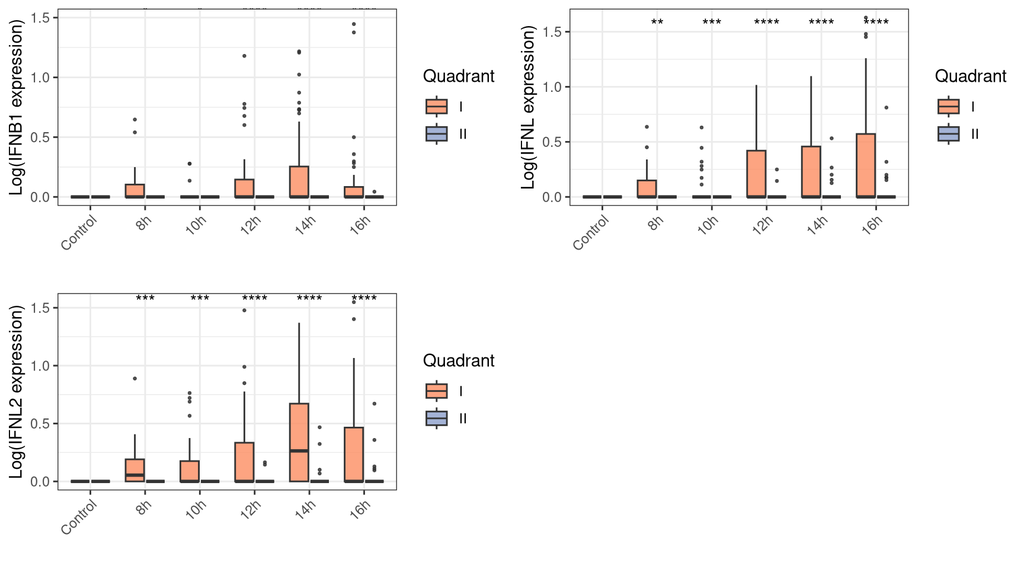

```r
p_ifnb1 <- md %>%
        filter(!is.na(quadrant_q)) %>%
ggplot(aes(x = time_discrete,
           y = log(IFNB1+1),
           fill = quadrant_q)) +
  geom_boxplot(outlier.size = 0.5, alpha = 0.8) +
        # Add p-values (I vs II within each timepoint)
  stat_compare_means(
    aes(group = quadrant_q),
    method = "wilcox.test",
    label = 'p.signif', label.y = 1.5
  ) +
  scale_fill_manual(values = cols) +
  labs(
    x = "",
    y = "Log(IFNB1 expression)",
    fill = "Quadrant"
  ) +
  theme_bw() +
  theme(axis.text.x = element_text(angle = 45, hjust = 1))


p_ifnl1 <- md %>%
        filter(!is.na(quadrant_q)) %>%
ggplot(aes(x = time_discrete,
           y = log(IFNL1+1),
           fill = quadrant_q)) +
  geom_boxplot(outlier.size = 0.5, alpha = 0.8) +
        # Add p-values (I vs II within each timepoint)
  stat_compare_means(
    aes(group = quadrant_q),
    method = "wilcox.test",
    label = 'p.signif', label.y = 1.5
  ) +
  scale_fill_manual(values = cols) +
  labs(
    x = "",
    y = "Log(IFNL expression)",
    fill = "Quadrant"
  ) +
  theme_bw() +
  theme(axis.text.x = element_text(angle = 45, hjust = 1))


p_ifnl2 <- md %>%
        filter(!is.na(quadrant_q)) %>%
ggplot(aes(x = time_discrete,
           y = log(IFNL2+1),
           fill = quadrant_q)) +
  geom_boxplot(outlier.size = 0.5, alpha = 0.8) +
        # Add p-values (I vs II within each timepoint)
  stat_compare_means(
    aes(group = quadrant_q),
    method = "wilcox.test",
    label = 'p.signif', label.y = 1.5
  ) +
  scale_fill_manual(values = cols) +
  labs(
    x = "",
    y = "Log(IFNL2 expression)",
    fill = "Quadrant"
  ) +
  theme_bw() +
  theme(axis.text.x = element_text(angle = 45, hjust = 1))


gridExtra::grid.arrange(
        p_ifnb1, p_ifnl1, p_ifnl2,
        ncol = 2
)
```

```r
pdf(paste0(path2figures,
           '/quantification_interferon_expression_rivera.pdf'),
    width=9.0, height=5.0)
gridExtra::grid.arrange(
        p_ifnb1,
        p_ifnl1, p_ifnl2,
        ncol = 2
)
dev.off()
```

# Proportion of cells per quadrant (panel `barplot_prop_quadrants_rivera.pdf`)

Fraction of all cells of each time point that fall into quadrant I or quadrant II (denominator includes unassigned cells).

```r
count_df_vs_all_cells <- md %>%
  group_by(time_discrete, quadrant_q) %>%
        summarise(n_cells=n())

prop_q_vs_all_cells_df <- count_df_vs_all_cells %>%
  group_by(time_discrete) %>%
  mutate(prop = n_cells / sum(n_cells))

write_tsv(prop_q_vs_all_cells_df,
          file = paste0(path2analysis, "/rivera_quadrant_proportions.tsv"))

barplot_prop_q_vs_all_cell <- prop_q_vs_all_cells_df %>%
        filter(!is.na(quadrant_q)) %>%
ggplot(aes(x = time_discrete,
                    y = prop,
                    fill = quadrant_q)) +
  geom_bar(stat = "identity", alpha = 0.8) +
        facet_wrap(~quadrant_q, scales = "free") +
  scale_fill_manual(values = cols) +
  labs(
    x = "",
    y = "Proportion of cells",
    fill = "Quadrant"
  ) +
  theme_bw() +
  theme(axis.text.x = element_text(angle = 45, hjust = 1),
        panel.grid = element_blank(),
        legend.position = 'none')

pdf(file = paste0(path2figures,
                  "/barplot_prop_quadrants_rivera.pdf"),
    width=5.0, height=2.5)
barplot_prop_q_vs_all_cell
dev.off()
```

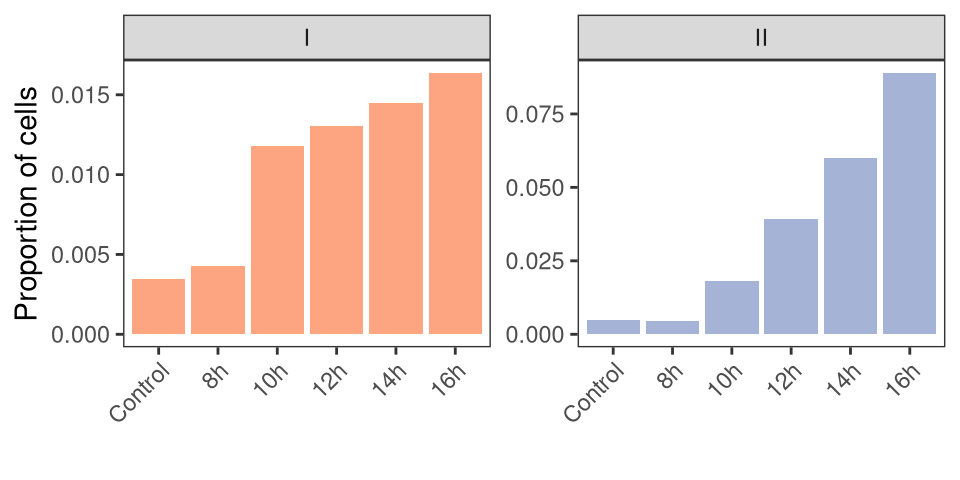

```r
barplot_prop_q_vs_all_cell
```

# IFNL1, OASL and viral load on the score plane (panel `oasl_ifnl1_ha_rigi_vs_stat.pdf`)

Infected cells (all time points except `Control`) on the RIG-I-only vs STAT-only plane, coloured by IFNL1, OASL or HA (viral) expression. Cells are sorted by the colour variable so that high expressers are drawn on top.

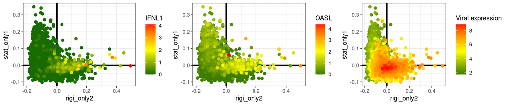

```r
ifnl1 <- md %>%
        filter(time_discrete!='Control') %>%
        arrange(IFNL1) %>%
        ggplot(aes(rigi_only2,
                   stat_only1,
                   colour = IFNL1)) +
        geom_hline(yintercept = 0, size = 1.2) +
         geom_vline(xintercept = 0, size = 1.2) +
           geom_point(size=2) +
                scale_colour_gradient2(
  low = "darkgreen",
  mid = "yellow",
  high = "red",
  midpoint = 2,
  name = "IFNL1"
  ) +
        theme_bw()

oasl <- md %>%
        filter(time_discrete!='Control') %>%
        arrange(OASL) %>%
        ggplot(aes(rigi_only2,
                   stat_only1,
                   colour = OASL)) +
        geom_hline(yintercept = 0, size = 1.2) +
         geom_vline(xintercept = 0, size = 1.2) +
           geom_point(size=2) +
                scale_colour_gradient2(
  low = "darkgreen",
  mid = "yellow",
  high = "red",
  midpoint = 2,
  name = "OASL"
  ) +
        theme_bw()

virus <- md %>%
        filter(time_discrete!='Control') %>%
        arrange(HA) %>%
        ggplot(aes(rigi_only2,
                   stat_only1,
                   colour = HA)) +
        geom_hline(yintercept = 0, size = 1.2) +
         geom_vline(xintercept = 0, size = 1.2) +
           geom_point(size=2) +
                scale_colour_gradient2(
  low = "darkgreen",
  mid = "yellow",
  high = "red",
  midpoint = 5,
  name = "Viral expression"
  ) +
        theme_bw()


gridExtra::grid.arrange(
        ifnl1, oasl, virus, ncol = 3
)
```

```r
pdf(file = paste0(path2figures,
                  '/oasl_ifnl1_ha_rigi_vs_stat.pdf'),
    height=2.5, width=12.0)
gridExtra::grid.arrange(
        ifnl1, oasl, virus, ncol = 3
)
dev.off()
```

# Viral load vs OASL and RIG-I-only score (panel `oasl_vs_rigi.pdf`)

Left: HA (viral) vs OASL expression of infected OASL-expressing cells. Right: HA vs RIG-I-only score of all infected cells. Points are coloured and sized by IFNL1 expression.

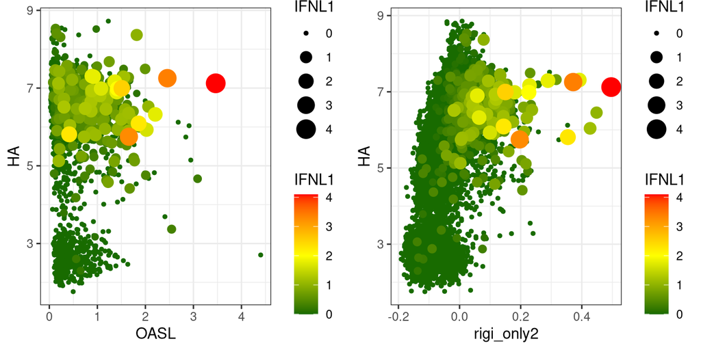

```r
oasl_vs_rigi_oasl <- md %>%
        filter(time_discrete!='Control') %>%
        filter(OASL > 0 ) %>%
        arrange(IFNL1) %>%
        ggplot(aes(OASL,HA,
                   colour = IFNL1,
                   size = IFNL1)) +
           geom_point() +
                scale_colour_gradient2(
  low = "darkgreen",
  mid = "yellow",
  high = "red",
  midpoint = 2,
  name = "IFNL1"
  ) +
        theme_bw()

oasl_vs_rigi_rigi <- md %>%
        filter(time_discrete!='Control') %>%
        arrange(IFNL1) %>%
        ggplot(aes(rigi_only2,HA,
                   colour = IFNL1,
                   size = IFNL1)) +
           geom_point() +
                scale_colour_gradient2(
  low = "darkgreen",
  mid = "yellow",
  high = "red",
  midpoint = 2,
  name = "IFNL1"
  ) +
        theme_bw()

gridExtra::grid.arrange(oasl_vs_rigi_oasl,
                        oasl_vs_rigi_rigi, ncol = 2)
```

```r
pdf(file = paste0(path2figures,
                  '/oasl_vs_rigi.pdf'),
    height=3.5, width=7)
gridExtra::grid.arrange(oasl_vs_rigi_oasl,
                        oasl_vs_rigi_rigi, ncol = 2)
dev.off()
```